# GammaSleep Results

Hainke, Dowsett, Spitschan, Priller

2024-01-16

# Sample Description

### Age

Mean = 24.53 y  
SD = 3.52 y  
Range = 20 – 30 y

### Sex

19 females *[1]*, 11 males *[2]*  
Mean = 1.37  
SD = 0.49

### Gender

Number of participants whose indicated gender did not match their sex assigned at birth: 0

### Handedness

28 right-handed *[1]*, 1 ambidextrous *[2]*, 1 left-handed *[3]*  
Mean = 1.1  
SD = 0.4

### Education

Minimal possible value: “Less than secondary education (no school degree or up to 7th grade)” *[0]*  
Maximal possible value: “Doctorate or equivalent” *[7]*

Mean = 4.53  
SD = 1.25  
Range = 3 – 6

### Baseline Sleep Quality

PSQI questionnaire sum score at screening. Only values <6 were accepted for recruitment.  
A score of 0 indicates perfect sleep quality in the prior month, a score of 21 indicates very disturbed sleep.

Mean = 3.7  
SD = 1.09  
Range = 1 – 5

### Chronotype

Midpoint between sleep onset and offset on work-free days, corrected for “oversleep” due to sleep debt accumulated over the workweek (MSFsc). Only values > 01:30 (“extremely early chronotype”) and < 06:30 (“extremely late chronotype”), as defined in Roenneberg et al. (2019), were accepted for recruitment.

Mean = 04:19:30  
Range = 01:52:00 – 06:15:00

# Confirmatory Analysis [EEG]

## Main Outcome: EEG Power Spectral Density

The power spectral density, or power spectrum, reflects the ‘frequency content’ of the EEG signal; in other words, how strongly each frequency contributes to the total signal. Our main variable was the power at 40 Hz, corresponding exactly to the visual stimulation frequency. Converted into the commonly employed dB scale, lower values closer to zero reflect a stronger power, and more negative values represent a weaker power.

## H1: W_exp > W_con

During wakefulness, 40 Hz power was expected to be higher in the experimental condition (session 01) than in the control condition (session 02). This hypothesis was **confirmed**, with a **large effect** size:

```
## RESULTS: PAIRED T-TEST
##
## P-value: 4.839085e-11
##
## Effect size:
## d (z) |       95% CI
## --------------------
## 1.75  | [1.19, 2.31]
##
## - Adjusted for small sample bias.
```

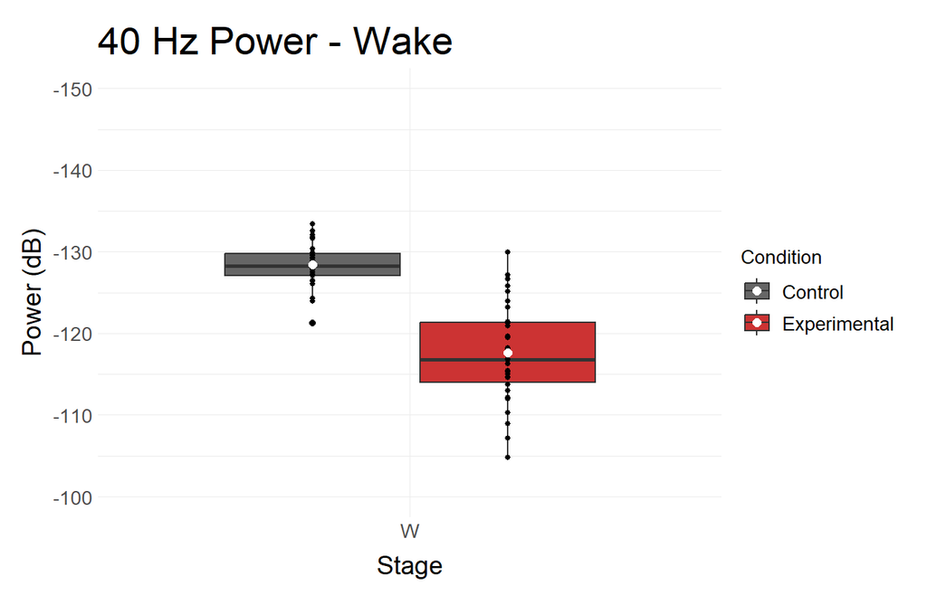

## H2: N2_exp > N2_con

During sleep stage N2, 40 Hz power was expected to be higher in the experimental condition (session 03) than in the control condition (session 02). This hypothesis was **confirmed**, with a **medium effect** size:

```
## RESULTS: PAIRED T-TEST
##
## P-value: 0.001285493
##
## Effect size:
## d (z) |       95% CI
## --------------------
## 0.59  | [0.21, 0.97]
##
## - Adjusted for small sample bias.
```

## H3: N3_exp > N3_con

During sleep stage N3, 40 Hz power was expected to be higher in the experimental condition (session 03) than in the control condition (session 02). This hypothesis was **confirmed**, with a **medium effect** size:

```
## RESULTS: PAIRED T-TEST
##
## P-value: 0.001856991
##
## Effect size:
## d (z) |       95% CI
## --------------------
## 0.56  | [0.18, 0.94]
##
## - Adjusted for small sample bias.
```

## H4: REM_exp > REM_con

During sleep stage REM, 40 Hz power was expected to be higher in the experimental condition (session 03) than in the control condition (session 02). This hypothesis was **confirmed**, with a **large effect** size:

```
## RESULTS: PAIRED WILCOXON SIGNED RANK TEST
##
## P-value: 1.275912e-07
##
## Effect size:
## r (rank biserial) |       95% CI
## --------------------------------
## 0.94              | [0.88, 1.00]
##
## - One-sided CIs: upper bound fixed at [1.00].
```

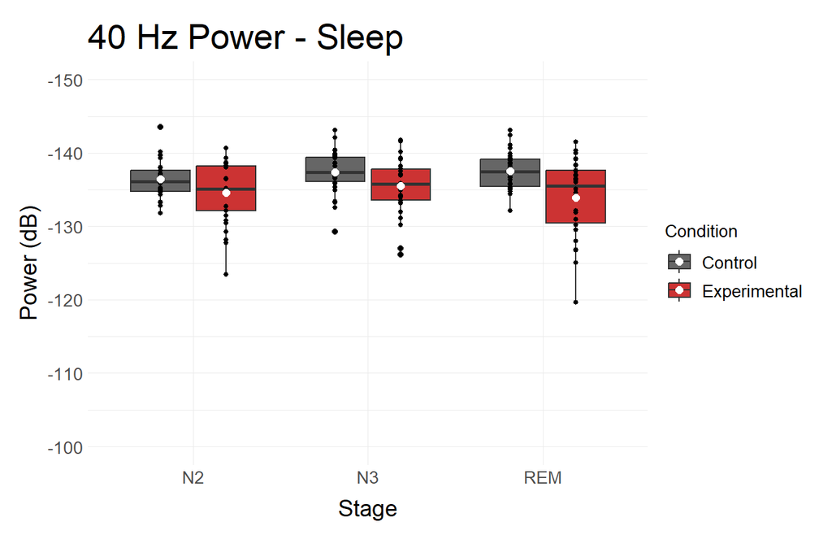

## H5: W_exp =/= N2_exp =/= N3_exp =/= REM_exp

In the experimental condition, 40 Hz power was expected to differ between stages. This hypothesis was **confirmed**, with a **large effect** size. However, post-hoc tests reveal that **only stage W differs** from all other stages, i.e., the stimulation effect is largest in W. There is no significant difference between the sleep stages N2, N3, and REM.

```
## RESULTS: REPEATED-MEASURES ANOVA
##
## P-value: 2.563751e-169
##
## # Effect Size for ANOVA
##
## Eta2 (partial) |   CI | CI_low
## ------------------------------
## 0.90           | 0.95 |   0.87
##
##
## Bonferroni-corrected post-hoc tests:
##               N2           N3         REM
## N3  1.000000e+00           NA          NA
## REM 1.000000e+00 1.000000e+00          NA
## W   1.368452e-24 2.714687e-26 2.00702e-23
```

## Signal-to-Noise Ratio

The Signal-to-Noise Ratio (SNR) for the variable 40 Hz power was computed as follows: for each condition and stage, take the single power value at 40 Hz in dB, and divide by the surrounding values ([38 Hz to 39.5 Hz] + [40.5 Hz to 42 Hz]). With this approach, individual 1/f distributions in the EEG are corrected for.  
An SNR value =< 1 means that EEG activity levels at 40 Hz and at neighbouring frequencies are similar; a higher SNR value signifies that the 40 Hz visual stimulation effect is clearly distinguishable from other brain activity.

Here are the **median SNR values**. Consistent with confirmatory analyses, all SNR values in the control condition are ~1, and all SNR values in the experimental condition are >1, with a markedly higher value in W<sub>exp</sub>.

```
##  stage condition     value
##     N2       con  1.047839
##     N3       con  1.025559
##    REM       con  1.045269
##      W       con  1.042527
##     N2       exp  2.010254
##     N3       exp  1.626257
##    REM       exp  2.411968
##      W       exp 17.068320
```

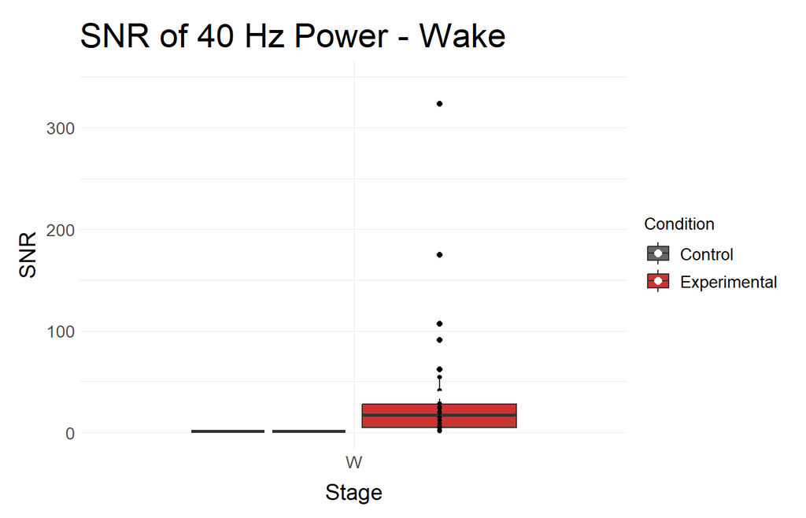

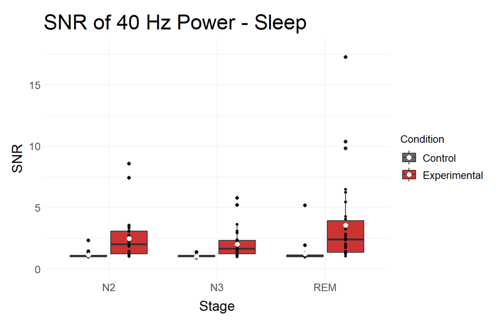

# Exploratory Analysis [EEG]

## Secondary Outcome: SSVEP Amplitude

Steady-State Visually Evoked Potentials were obtained by taking every flicker onset as timepoint zero, and averaging across all 25 ms segments (1 second divided by 40 Hz), stratified by condition and stage. In the control condition, LEDs were covered, so flat lines were expected; in the experimental condition, sinusoidal waveforms with a period of 25 ms were expected. The peak-to-trough amplitude in microvolt can be used for analyses, with higher values representing a stronger stimulation effect.

The following plots depict the **SSVEPs averaged** across all subjects, by stage and condition.

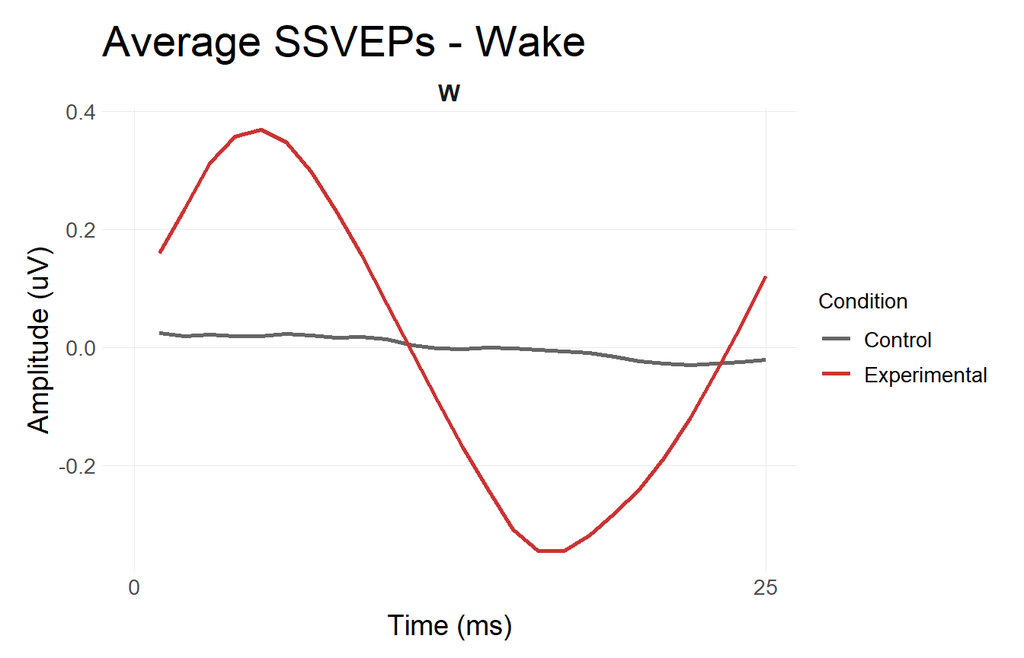

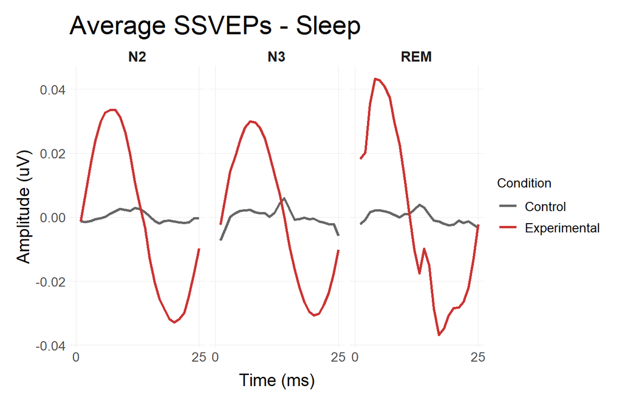

**Note:** This variable is of course highly correlated with PSD values, since both are computed from the same underlying data. However, inspecting SSVEP waveforms allows us to show that the results are really attributable to the stimulation, not to any high-frequency artifact such as muscle activity, since the latter would get averaged out. Moreover, any electric artifacts from the LEDs become visible. A slight artifact seems to be present in N3<sub>con</sub> and REM<sub>con</sub>, though its amplitude is much smaller than the SSVEPs’ of the corresponding experimental conditions.

## H1: W_exp > W_con

During wakefulness, SSVEP amplitude was expected to be higher in the experimental condition (session 01) than in the control condition (session 02). This hypothesis was **confirmed**, with a **large effect** size:

```
## RESULTS: PAIRED WILCOXON SIGNED RANK TEST
##
## P-value: 4.656613e-09
##
## Effect size:
## r (rank biserial) |       95% CI
## --------------------------------
## 0.99              | [0.97, 1.00]
##
## - One-sided CIs: upper bound fixed at [1.00].
```

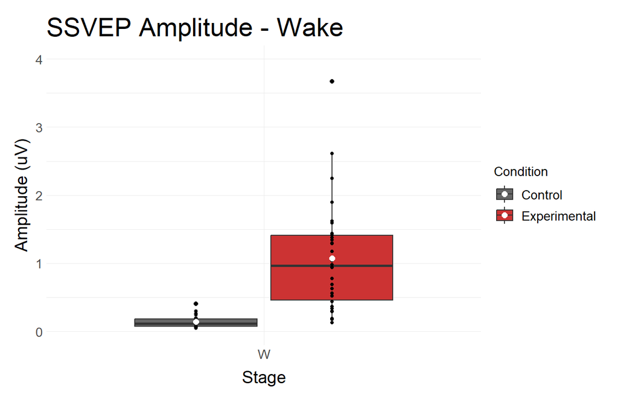

## H2: N2_exp > N2_con

During sleep stage N2, SSVEP amplitude was expected to be higher in the experimental condition (session 03) than in the control condition (session 02). This hypothesis was **confirmed**, with a **large effect** size:

```
## RESULTS: PAIRED WILCOXON SIGNED RANK TEST
##
## P-value: 1.381151e-06
##
## Effect size:
## r (rank biserial) |       95% CI
## --------------------------------
## 0.88              | [0.77, 1.00]
##
## - One-sided CIs: upper bound fixed at [1.00].
```

## H3: N3_exp > N3_con

```
## RESULTS: PAIRED T-TEST
##
## P-value: 0.0002489003
##
## Effect size:
## d (z) |       95% CI
## --------------------
## 0.70  | [0.31, 1.09]
##
## - Adjusted for small sample bias.
```

## H4: REM_exp > REM_con

During sleep stage REM, SSVEP amplitude was expected to be higher in the experimental condition (session 03) than in the control condition (session 02). This hypothesis was **confirmed**, with a **large effect** size:

```
## RESULTS: PAIRED WILCOXON SIGNED RANK TEST
##
## P-value: 1.183338e-05
##
## Effect size:
## r (rank biserial) |       95% CI
## --------------------------------
## 0.82              | [0.66, 1.00]
##
## - One-sided CIs: upper bound fixed at [1.00].
```

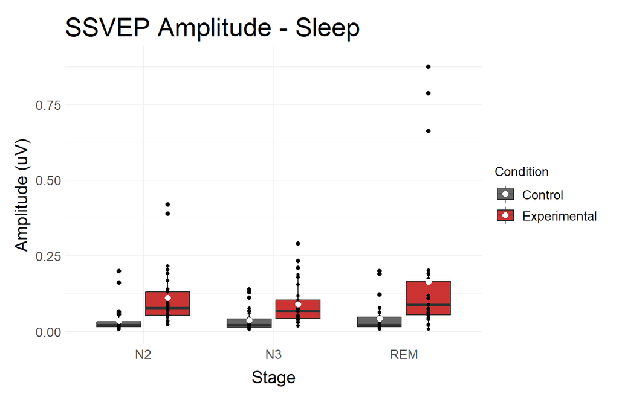

## H5: W_exp =/= N2_exp =/= N3_exp =/= REM_exp

In the experimental condition, SSVEP amplitude was expected to differ between stages. This hypothesis was **confirmed**, with a **large effect** size. However, post-hoc tests reveal that **only stage W differs** from all other stages, i.e., the stimulation effect is largest in W. There is no significant difference between the sleep stages N2, N3, and REM.

```
## RESULTS: FRIEDMAN TEST
##
## P-value: 4.04447e-13
##
## Kendall's W |       95% CI
## --------------------------
## 0.68        | [0.62, 1.00]
##
## - One-sided CIs: upper bound fixed at [1.00].
##
## Bonferroni-corrected post-hoc tests:
##               N2           N3         REM
## N3  1.000000e+00           NA          NA
## REM 1.000000e+00 9.810482e-01          NA
## W   1.495832e-12 5.154544e-14 1.53617e-10
```

## Signal-to-Noise Ratio

The Signal-to-Noise Ratio (SNR) for the variable SSVEP amplitude was computed as follows: for each condition and stage, take every 25 ms segment and shuffle the order of data points. Average over segments to create a “random” SSVEP and calculate its peak to trough amplitude. Repeat 100 times. The SNR is the ratio of the “true” SSVEP amplitude to the average of the “random” SSVEP amplitudes.  
An SNR value =< 1 means that the averaged signal contains no clear temporal structure; a higher SNR value indicates that the EEG activity measured differs meaningfully from random activity.

Here are the **median SNR values**. Consistent with confirmatory analyses, all SNR values in the control condition are ~1, and all SNR values in the experimental condition are >1, with a markedly higher value in W_exp.

```
##  stage condition     value
##     N2       con 0.8527998
##     N3       con 0.5910849
##    REM       con 0.7655222
##      W       con 1.1881686
##     N2       exp 2.6317243
##     N3       exp 1.6803954
##    REM       exp 2.8148168
##      W       exp 6.2597261
```

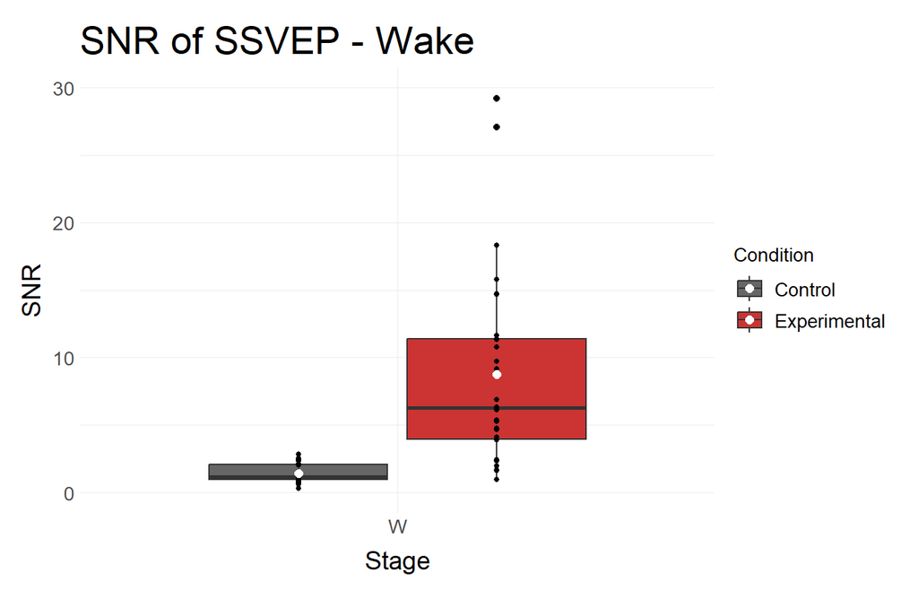

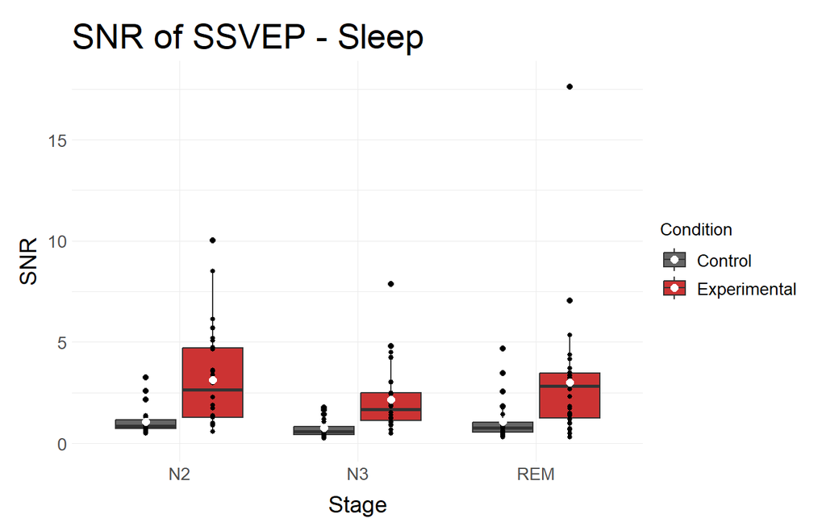

## Stimulation Time

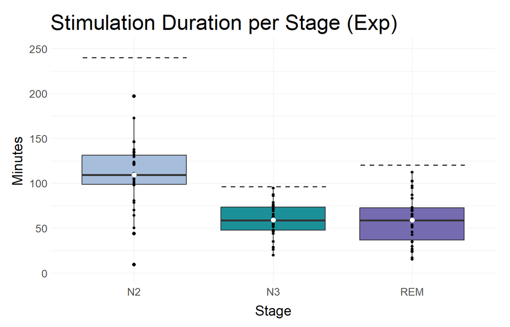

# Exploratory Analysis [Sleep]

## Subjective Sleep Quality

The Groningen Sleep Quality Questionnaire (Mejiman et al., 1988) measures the subjective quality of last night’s sleep, based on yes/no answers. A minimal score of 0 indicates perfect sleep quality, a maximal score of 14 reflects very poor sleep quality.  
A two-sided test was **significant** with a **small effect** size, showing that on average, subjectively assessed sleep quality was better in the experimental than in the control night.

```
## RESULTS: PAIRED T-TEST
##
## P-value: 0.01136234
##
## Effect size:
## d (z) |       95% CI
## --------------------
## 0.48  | [0.11, 0.85]
##
## - Adjusted for small sample bias.
```

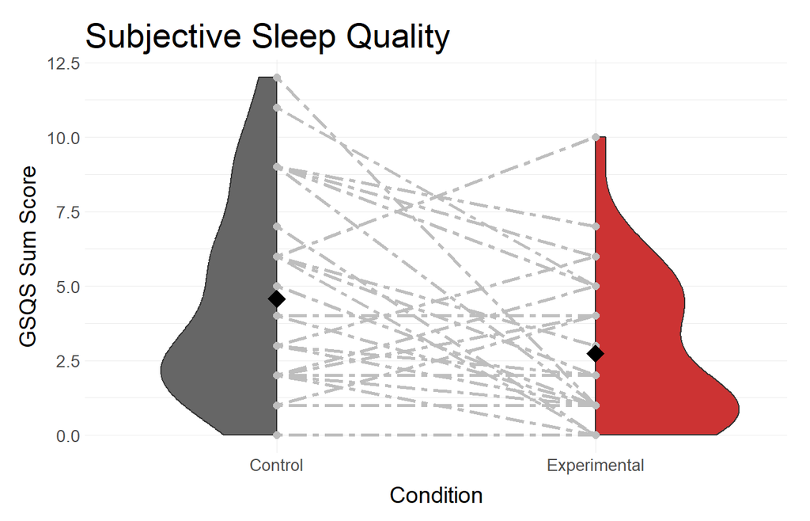

## Total Sleep Time

Total Sleep Time (TST) quantifies the total duration of N1 + N2 + N3 + REM sleep in a night in minutes, as one marker of objective sleep quality. A minimal value of 0 would be equivalent to a night spent awake; its maximal value is 480 min, i.e., a full recording duration of 8 hours. It was calculated using the Python package YASA and its algorithm for automated sleep staging (Vallat & Walker, 2021).  
A two-sided test was **not significant**, showing that on average, participants slept for a similarly long time in both the control and experimental nights.

```
## RESULTS: PAIRED T-TEST
##
## P-value: 0.9091449
##
## Effect size:
## d (z) |        95% CI
## ---------------------
## -0.02 | [-0.37, 0.33]
##
## - Adjusted for small sample bias.
```

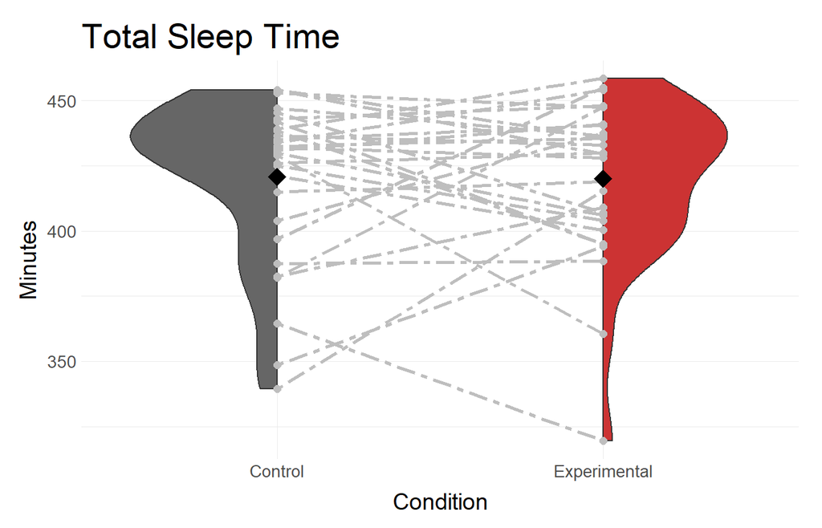

## Wake After Sleep Onset

Wake After Sleep Onset (WASO) is another marker of objectively assessed sleep quality. It quantifies the summed duration of wake periods overnight in minutes, within the span from the first to the last period of sleep. A minimal value of 0 would mean that between falling asleep and waking up, the subject fully slept through. A higher value (max. 479 min) can point to a few longer periods awake, or multiple short awakenings. It was also calculated using the Python package YASA.  
A two-sided test was **not significant**, showing that on average, participants spent a similar amount of time awake overnight in both the control and experimental nights. The relatively high values overall are likely due to sleeping in a foreign environment with electrodes and a mask on the head, and/or the visual stimulation, equally unfamiliar to subjects.

```
## RESULTS: PAIRED T-TEST
##
## P-value: 0.1632263
##
## Effect size:
## d (z) |        95% CI
## ---------------------
## -0.25 | [-0.61, 0.10]
##
## - Adjusted for small sample bias.
```

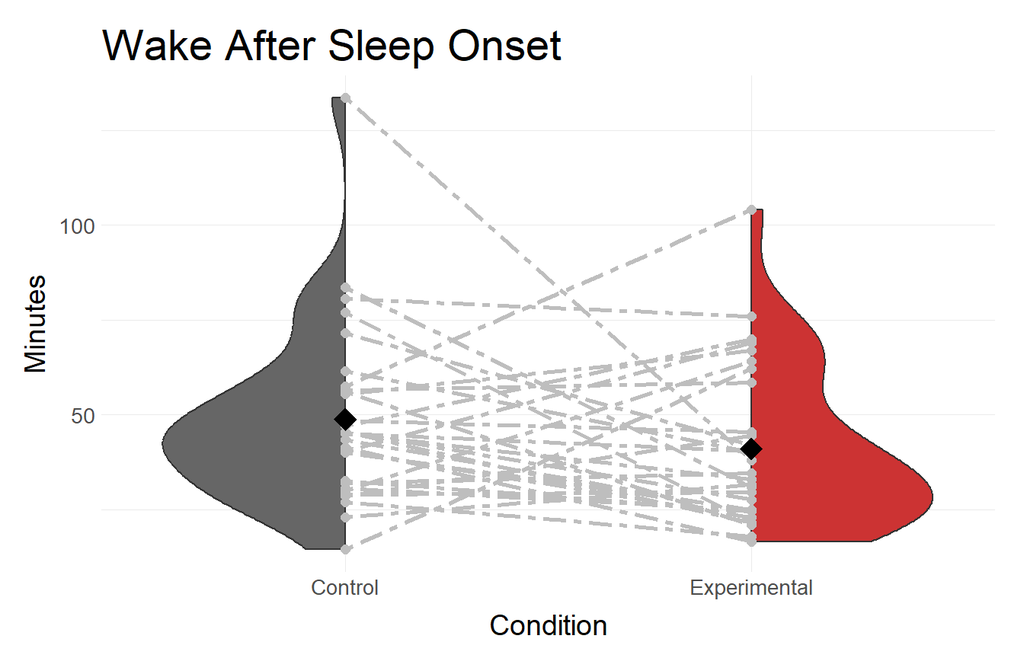

## Time per Stage

Time per Stage specifies the duration of each sleep stage as a percentage of TST %(N1,…REM). No statistical tests were planned for this variable, so it is reported descriptively. The plot below shows a **sleep stage distribution common** for healthy, young sleepers on **both nights**, with values for N1 ~ 5 %, N2 ~ 50 %, N3 ~ 20 %, and REM ~ 25 %.

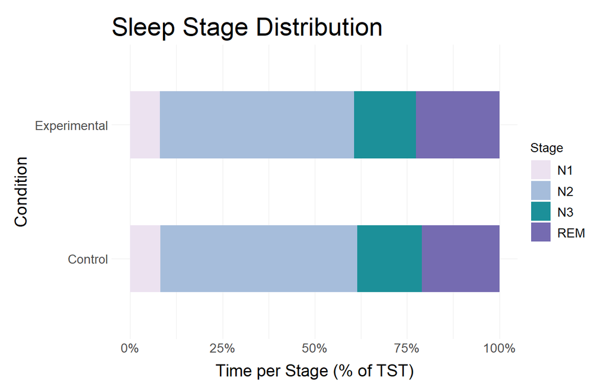

## Note on the Interpretation of Sleep Quality Results

Since the order of control and experimental nights was held constant across participants, and no adaptation night was included in the design, a fair comparison between both conditions regarding sleep quality is not possible. However, summarizing the exploratory sleep variables analysed, we may conclude that the intervention (in night 2, experimental condition) affects subjective and objective sleep quality equally to or less than the First Night Effect (in night 1, control condition).